*N* removed NAs: 3

*N* removed <18: 19

*N* total clean: 126

| Group | *N* | *M*<sub>age</sub> | *M*<sub>rating</sub> |
| --- | --- | --- | --- |
| Control | 64 | 21.06 | 5.99 |
| Experim | 62 | 20.82 | 6.98 |

**Main analysis results**

*t*(124) = -6.53, *p* < .001

# Coursework Report

Analysing Data, Spring 2020

# Methods

## Participants

Table 1 *Descriptive statistics by experimental condition*

| Experimental condition | *N* | % | *M*<sub>age</sub> | *SD*<sub>age</sub> |
| --- | --- | --- | --- | --- |
| Red | 64 | 50.79 | 21.06 | 2.43 |
| White | 62 | 49.21 | 20.82 | 2.48 |

## Design

# Results

An independant-samples *t* test revealed a significant difference in the mean attractiveness ratings of the red vs white colour groups (*M*diff~ = -0.99, 95% CI [-1.29, -0.69]) (*t*(124) = -6.53, *p* = <.001). The results showed that participants in the white control colour condition rated the man higher in levels of attractiveness than those in the red experimental condition. The results of this experiment indicate the opposite to those found in the previous study (Elliot et al, 2010). In contrast we found that not only did the colour red not seem to influence how attractive women find a man in combination with the colour red, but that reported levels of attractiveness were actually higher in the control group. This experiment did not support our hypothesis, and found dissimilar results pattern to those found in previous study (Elliot et al, 2010).

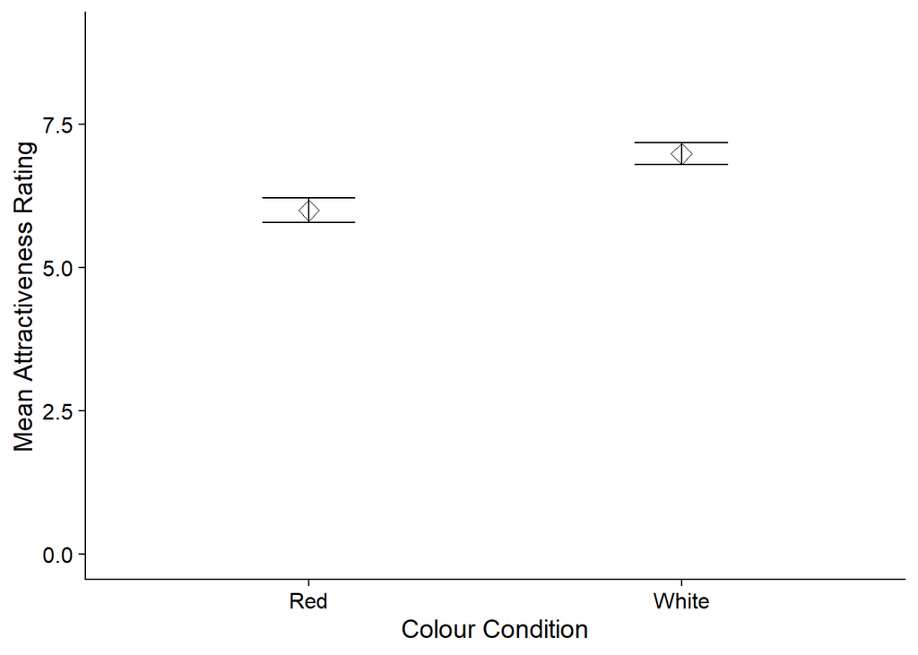

# Discussion

This experiment had interesting results, female participates rated a man as more attractive on average, when their photograph was in a white background, in comparison to the same male with a red background. This contrasted many previous studies, including the study we replicated. Elliot et al (2010), found that participants rated the male as more attractive in association with red than that of white. Publication bias may have lead to the interpretation of the findings of the original Elliot et al (2010) study, however. A further investigation into the findings, found that due to the small sample sizes, the power is quite low and the participants may have been interpreting the males with red as having higher power status rather than being attractive (Francis, 2013). Another similar replication of the Elliot et al (2010) study, found no significicant impact of red in two seperate experiments, and thus questioned the ecological validity of the original study (Hesslinger, Goldbach & Carbon, 2015). It could be questioned whether there is any difference between males or females and any effect on red and attractiveness, a recent study examined whether men would find women dressed in red as more attractive, but found no significant difference in comparison to being dressed in black or white instead (Peperkoorn, Roberts, & Pollet, 2016). Our results confounded the studies mentioned, finding no signficant effect on the colour red for reported levels of attraction, this indicates that the original Elliot et al (2010) is not a reliable source as it is not replicable. In the current study, we did find a significant effect on the white background in levels or attractiveness, which could be a future avenue of study, and what other factors may have possibly contributed to this effect. The conclusions we have made from the study, is that we found no significant effect on ratings of attraction and the colour red, we can take away from this that the Elliot et al (2010) study cannot be easily replicated, and findings vary dramatically when they are repeated on different samples. I would conclude that the study isn’t ecologically valid as what is deemed as “attractive” is a lot more than a black and white photograph and it is unlikely that changing the background colour makes any real difference to how attrative the viewer finds them. One clear strength of the current study is the relatively large sample size, which may suggest a reason for such different results to the Elliot et al (2010) study, being able to use a composite score in relation to three seperate questions relating to the mans attractiveness led to more accurate results than if participants were just asked one. One potential limitation to the current study was how red was classified, although many research areas have shown a link between the colour red and levels of attractiveness, it could be argued that the male photograph with a red background is not associated strongly enough with the colour. Research has shown, for example that redness of the face positively influences perceptions of attractiveness and health for women viewing men, giving a positive evolutionary explanation in terms of reproduction (Thorstenson et al, 2016). Whilst using red as a background colour against the males photograph may subconsciously influence a woman to associate him with red, as it has not changed his photograph the effect may be expected to be lessened.

# References

Elliot, A. J., Niesta, K. D., Greitmeyer, T., Lichtenfeld, S., & Gramzow, R. H. (2010). Red, rank and romance in women viewing men. Journal of Experimental Psychology, 139(3), 399-417.

Francis, G. (2013, Feb). Publication bias in “Red, rank and romance in women viewing men,” by Elliot et al (2010). Journal of Experimental Psychology: General, 142(1), 292-296.

Hesslinger, V. M., Goldbach, L., & Carbon, C.-C. (2015). Men in red: A reexamination of the red-attractiveness effect. Psychonomic Bulletin & Review, 22, 1142-1148.

Peperkoorn, L. S., Roberts, C., & Pollet, T. V. (2016, December 6). Revisiting the Red Effect on Attractiveness and Sexual Receptivity: No Effect of the Color Red on Human Mate Preferences. Retrieved from Sage Journals: https://doi.org/10.1177/1474704916673841

Thorstenson, C. A., Pazda, A. D., Elliot, A. J., & Perrett, D. I. (2016). Facial Redness Increases Men’s Perceieved Healthiness and Attractiveness. Perception, 46(6), 650-664.